# Differential Gene Expression Analysis of a Dystrophin Mutation on Heart Tissues

Hugo Hudson

# Introduction

# Gene Identifier Mapping

### Dataset Setup

Initially, to start gene identifier mapping the relevant packages are loaded as well as querying the GEO accession identifier for the study. In this case the samples were all present in a single compressed comma separated file, removing the need for any concatenation of files. Given that this analysis is focusing on the shift in expression from the control 3D culture to mutation induced 3D, the data is subset to include only the 3D cell cultures for optimized analysis.

```r
library(GEOquery)
library(biomaRt)
library(readr)
library(dplyr)
library(stringr)
library(limma)
library(ggplot2)
library(knitr)
library(ComplexHeatmap)
library(patchwork)

# If not downloaded query the data:
ACCESION_ID <- "GSE199242"
dir.create("data")
supp <- GEOquery::getGEOSuppFiles(ACCESION_ID, makeDirectory = TRUE, baseDir="data")

# Load in the counts matrix, it is already provided with columns corresponding to samples
counts_matrix <- readr::read_csv("data/GSE199242/GSE199242_countMatrix_2D+3D.csv.gz", show_col_types=FALSE)

# Since the data also contains for 2D organoid, that should be excluded for memory management as well as length column
matrix_excluding_2d <- counts_matrix[,1:8]
relevant_counts_matrix <- matrix_excluding_2d[,-2]
```

### Mapping To HGNC

The formatted counts matrix contains the number of reads per sample for each ensembl identifier. In this case, we want to work with the more intepretable HGNC gene names, so the ensembl identifiers are removed of their versions to map more generally to HGNC using the bioMart package. In doing so, I identified 18188 genes that did not have an equivalent HUGO gene identifier and 56 genes having a non-unique HUGO identifier within the dataset. Ensembl genes unable to map to HGNC were removed from downstream processing to evaluate the gene expression changes of common known genes. The duplicated expression values are summed to preserve any signal from different isoforms or incomplete read matches, as opposed to losing signal through averaging.

```r
# Remove versions of Ensembl identifiers and add them as a new column for mapping.
stripped_ids <- sapply(strsplit(relevant_counts_matrix$GeneID, split = ".", fixed =TRUE), function(x) x[1])
relevant_counts_matrix$ensembl_gene_id <- stripped_ids

# Setup BioMart - Version 115 is pinned to keep results consistent in case of new release.
ensembl_version <- useEnsembl(biomart = "ensembl", version = "115")

# Specify the human ensembl gene identifiers out of available organisms
ensembl_dataset <- useDataset("hsapiens_gene_ensembl", mart=ensembl_version)

# Map from Ensembl to HUGO (HGNC identifiers)
gene_ensembl_to_hgnc_mapping <- getBM(attributes = c("ensembl_gene_id", "hgnc_symbol"), filters="ensembl_gene_id", values=relevant_counts_matrix$ensembl_gene_id, mart= ensembl_dataset)

# Add HGNC as a column
hgnc_matrix <- merge(relevant_counts_matrix, gene_ensembl_to_hgnc_mapping, by="ensembl_gene_id")

# Remove unmapped genes (no hgnc symbol found)
mapped_only_matrix <- hgnc_matrix[hgnc_matrix$hgnc_symbol != "", ]
# Sum the counts of duplicate genes as we need unique gene symbols
samples_start_idx = 3
samples_end_idx = 8
unique_counts_matrix <- rowsum(mapped_only_matrix[samples_start_idx:samples_end_idx], group = mapped_only_matrix$hgnc_symbol)

# print(paste("Number of unmapped genes:", sum(hgnc_matrix$hgnc_symbol == "")))
# print(paste("Number of duplicate genes:", sum(duplicated(mapped_only_matrix$hgnc_symbol))))

# Data checkpoint - saving the mapped matrix pre-filtering & normalization
dir.create("data/checkpoints")
saveRDS(unique_counts_matrix, "data/checkpoints/matrix_preQC.rds")
```

# Data Normalization

### Pre-Quality Control Visualization

To fully assses the data quality both between the samples and between the groups, a boxplot and density plot are used.

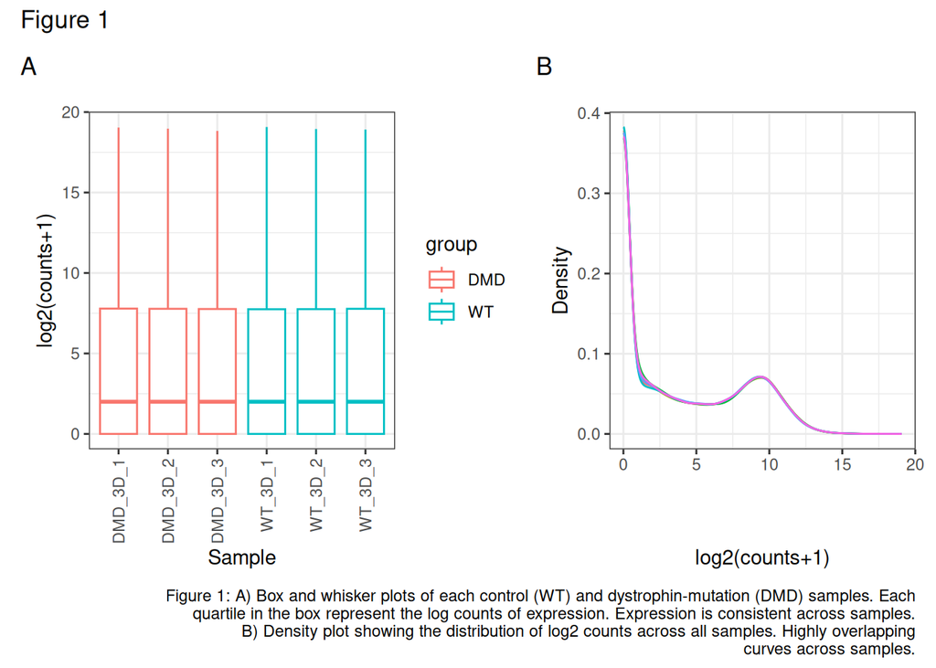

```r
### Flatten the dataframe using pivot longer to get the counts for each gene from a sample, then log transform for box plot.
plot_box <- function(counts_matrix, title = "", ylab = "log2(counts+1)") {
  flattened_df <- counts_matrix |>
    tidyr::pivot_longer(-hgnc_symbol, names_to = "sample_id", values_to = "value") |>
    mutate(group = word(sample_id, 1, sep="_"))  |>
    mutate(value = log2(value + 1))

  ggplot(flattened_df, aes(x = sample_id, y = value, colour = group)) +
    geom_boxplot(outlier.size = 0.2) +
    theme_bw() +
    theme(axis.text.x = element_text(angle = 90, vjust = 0.5, hjust = 1)) +
    labs(title = title, x = "Sample", y = ylab)
}
box <- plot_box(cbind(unique_counts_matrix, hgnc_symbol = rownames(unique_counts_matrix)))


# Flatten the data frame again to get per gene per sample counts then use ggplot density function
plot_density <- function(counts_matrix, main = "") {
  flattened_df <- counts_matrix |>
    tidyr::pivot_longer(-hgnc_symbol, names_to = "sample_id", values_to = "value") |>
    mutate(group = word(sample_id, 1, sep="_"))  |>
    mutate(value = log2(value + 1))

  ggplot(flattened_df, aes(x = value, colour = sample_id)) +
    geom_density() +
    theme_bw() +
    labs(title = main, x = "log2(counts+1)", y = "Density") +
    guides(colour = "none")
}

### Combine into side by side plots
density_dist <- plot_density(cbind(unique_counts_matrix, hgnc_symbol = rownames(unique_counts_matrix)))
box + density_dist + plot_annotation(tag_levels="A", title="Figure 1", caption = str_wrap("Figure 1: A) Box and whisker plots of each control (WT) and dystrophin-mutation (DMD) samples. Each quartile in the box represent the log counts of expression. Expression is consistent across samples. B) Density plot showing the distribution of log2 counts across all samples. Highly overlapping curves across samples.", width = 100))
```

The quartiles in figure 1A with the lower, median and upper are consistent across all samples with red and blue indicating that within and across groups demonstrate this consitency in reads throughout. The upper whisker does deviate partially between each sample suggesting a differing maximum number of reads expressed in each sample with sample 1 having the highest expression in both the control and mutation groups. Regarding the density of reads found there is a peak around 10 log2 counts and a global peak at 0 suggesting that most genes do not have any expression and for genes that are expressed this is mostly at around a frequency of 10 log2counts. Additionally, the uniform nature of the samples across the density distributions is indicative of consistent coverage captured across each of the samples.

### Filtering & Normalization

The data is filtered prior to normalization to facilitate a more biologically accurate normalization. The samples are grouped using a design matrix based on if they are a part of the control group or the mutation-containing group. Then any missing values are removed as well as values below 3 reads which preserves the gene if this threshold is met in at least one group. Group based filtering of expression is useful as it preserves low counts in the event that it is consistent in a group to retain biological variation. Based on Figure panels 1A and 1B there are no identifiable outliers in read coverage, moreover all samples will be used.

```r
# Load from checkpoint if previously saved
if (file.exists("data/checkpoints/matrix_preQC.rds")) hgnc_matrix <- readRDS("data/checkpoints/matrix_preQC.rds")

samples_start_idx = 3
samples_end_idx = 8
min_reads = 3

# Build list of sample groups - by indexing for WT substring
mutation_mask <- rep(FALSE,length(unique_counts_matrix))
mutation_mask[grep(pattern="WT", colnames(unique_counts_matrix))] <- TRUE
# Convert boolean mask to the group names
groups <- ifelse(mutation_mask,"wildtype","mutation")

# Creating a design matrix corresponding to control vs mutation-present groups
group_design_mat <- model.matrix(~ 0 + groups)

# Check for NA / Filter
unique_counts_matrix <- unique_counts_matrix[-which(is.na(unique_counts_matrix)),]

# Use design matrix to filter out small number of reads - if present throughout group then kept
passing_genes_idx <- edgeR::filterByExpr(unique_counts_matrix, min.count = min_reads, design = group_design_mat)
filtered_genes_counts <- unique_counts_matrix[passing_genes_idx,]

# Data normalization via TMM
dge <- edgeR::DGEList(counts = filtered_genes_counts, group = groups)
dge_with_norm_factors <- edgeR::calcNormFactors(dge, method = "TMM")
```

### Post-Normalization Visualization

After transforming the counts with normalization the resulting matrix can be replotted for comparing read coverage similar to figure 1.

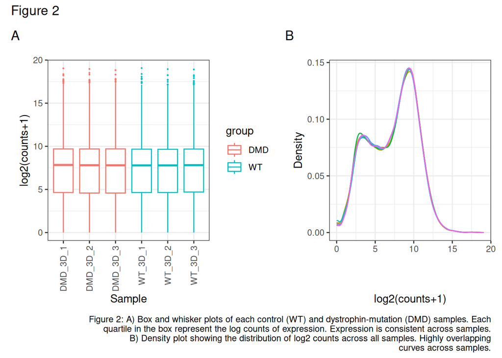

```r
# Takes dataframe, so convert from matrix to df
normalied_counts_df <- as.data.frame(dge_with_norm_factors$counts)
# Add the gene names as a column
normalied_counts_df <- cbind(normalied_counts_df, hgnc_symbol = rownames(dge_with_norm_factors))
# Call each plotting function
post_norm_box <- plot_box(normalied_counts_df)
post_norm_density <- plot_density(normalied_counts_df)
post_norm_box + post_norm_density + plot_annotation(tag_levels="A", title="Figure 2", caption = str_wrap("Figure 2: A) Box and whisker plots of each control (WT) and dystrophin-mutation (DMD) samples. Each quartile in the box represent the log counts of expression. Expression is consistent across samples. B) Density plot showing the distribution of log2 counts across all samples. Highly overlapping curves across samples.", width = 100))
```

# Differential Gene Expression

### Performing Differential Expression

Due to the limited number of replicates in the study, limma was selected for differential expression analysis (Ritchie et al. (2015)). Due to the Bayesian approach utilized in its model fitting it adjusts the variance per gene to achieve a common variance value which is beneficial for the few samples as it can reduce the impact of incidental fluctuations in reads on the remaining samples in the group. First, a linear model is fit, then the difference between the mutation-induced and control group is computed and finally the variance is adjusted calculating the differentially expressed genes.

```r
if (file.exists("data/checkpoints/matrix_postNorm.rds")) {
  norm_rds <- readRDS("data/checkpoints/matrix_postNorm.rds")
  dge_with_norm_factors <- norm_rds$dge_with_norm_factors
}

# Log2 CPM transform the counts (also takes the normalization factors into account)
cpm_transform <- voom(dge_with_norm_factors, group_design_mat)
# Fit general linear model with coefficient for groups
initial_model_fit <- lmFit(cpm_transform, group_design_mat)

# Fit mutation with respect to wild type
cont.matrix <- makeContrasts('MutVSwt' = groupsmutation - groupswildtype, levels=group_design_mat)
initial_contrasts_fit <- contrasts.fit(initial_model_fit, cont.matrix)
# Fit variance adjusted model
fit_contrasts <- eBayes(initial_contrasts_fit)

# Visualize results via p-value
model_results <- topTable(fit_contrasts, coef = "MutVSwt", number = Inf, sort.by="P")
kable(head(model_results,20), caption="Top 20 Differentially Expressed genes")
```

Top 20 Differentially Expressed genes

|  | logFC | AveExpr | t | P.Value | adj.P.Val | B |
| --- | --- | --- | --- | --- | --- | --- |
| BRINP3 | 1.6231734 | 4.597002 | 16.22822 | 0 | 0 | 25.20466 |
| STEAP3 | -1.1915602 | 7.312274 | -14.90263 | 0 | 0 | 23.81341 |
| TXNIP | -0.8386962 | 9.099156 | -13.22104 | 0 | 0 | 20.97474 |
| TECRL | 0.9025188 | 7.528328 | 12.96979 | 0 | 0 | 20.50912 |
| FOXO1 | 1.1502283 | 5.183393 | 12.96366 | 0 | 0 | 20.35709 |
| CLIC3 | -3.2764345 | 1.921354 | -12.70758 | 0 | 0 | 15.53868 |
| KRT14 | -3.0003743 | 2.853996 | -12.61028 | 0 | 0 | 17.66253 |
| IFI6 | -1.9017607 | 5.384239 | -12.54578 | 0 | 0 | 19.61219 |
| IFI44L | -1.7979134 | 5.282625 | -12.49618 | 0 | 0 | 19.51146 |
| CDK18 | -1.3446912 | 6.234741 | -12.23590 | 0 | 0 | 19.12123 |
| PRELP | -1.1284534 | 5.847153 | -11.72671 | 0 | 0 | 18.13557 |
| DLK1 | 2.0405737 | 3.042105 | 11.72387 | 0 | 0 | 16.97666 |
| AQP1 | -1.2665643 | 4.179461 | -11.68385 | 0 | 0 | 17.79062 |
| EPHA4 | 1.0343622 | 6.056696 | 11.40488 | 0 | 0 | 17.51263 |
| GJA5 | 1.0989289 | 5.836798 | 11.37036 | 0 | 0 | 17.43758 |
| NQO1 | 1.1035267 | 4.942188 | 11.30633 | 0 | 0 | 17.24778 |
| ANGPT1 | 1.2764743 | 4.360943 | 11.17475 | 0 | 0 | 16.87965 |
| TGM2 | 0.6966126 | 9.432286 | 11.11761 | 0 | 0 | 16.93131 |
| IL20RB | -1.2699152 | 4.008095 | -11.01453 | 0 | 0 | 16.47045 |
| NRXN1 | 1.3381693 | 3.963968 | 10.85742 | 0 | 0 | 16.14443 |

```r
# print(paste("Number of genes passing correction", length(model_results$adj.P.Val < 0.05)))
```

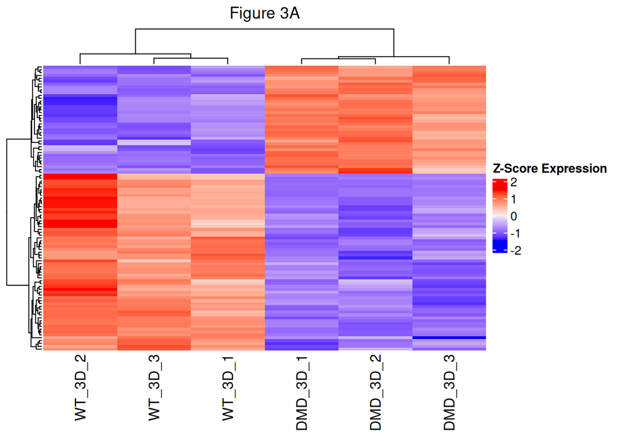

```r
# filter for top hits by p-value then map to their cpm
number_genes_to_show = 100
heatmap_matrix_top_hits <- cpm_transform$E[rownames(model_results[1:number_genes_to_show,]),]

z_score_cpm_matrix <- t(scale(t(heatmap_matrix_top_hits)))
p_value <- Heatmap(z_score_cpm_matrix, show_row_names = FALSE, name="Z-Score Expression", column_title = "Figure 3A")
p_value
```

1. Heatmap of expression counts (in counts-per-million) of the top 100 most signficantly changed genes using p-value.

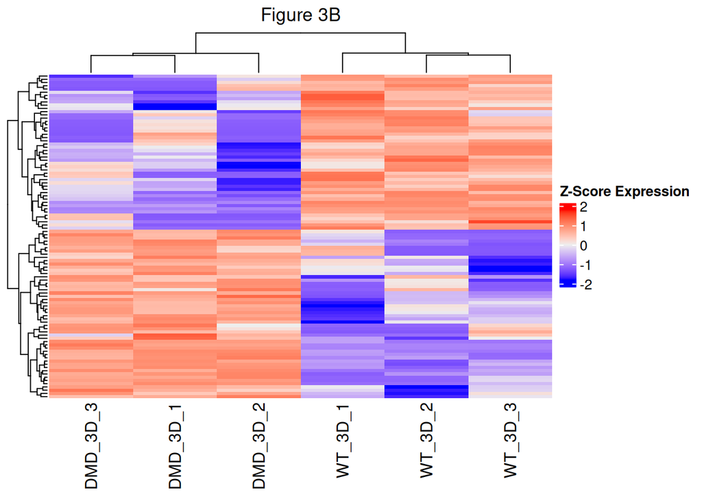

```r
model_results_FC <- topTable(fit_contrasts, number = Inf, sort.by = "logFC")
heatmap_matrix_top_hits_FC <- cpm_transform$E[rownames(model_results_FC[1:number_genes_to_show,]),]
z_score_cpm_matrix_FC <- t(scale(t(heatmap_matrix_top_hits_FC)))
logfc <- Heatmap(z_score_cpm_matrix_FC, show_row_names = FALSE, name="Z-Score Expression", column_title = "Figure 3B")
logfc
```

2. Heatmap of expression counts (in counts-per-million) of the top 100 most log fold changed genes.

### Visualizing DEG

To visualize the significance of changes in gene expression a volcano plot can be and here the significance threshold uses false discovery rate (FDR) adjusted p-value. FDR is used to account for the large amount of false positives with the large amount of genes being used here as it transforms the p-value to be more stringent for signifance passing values.

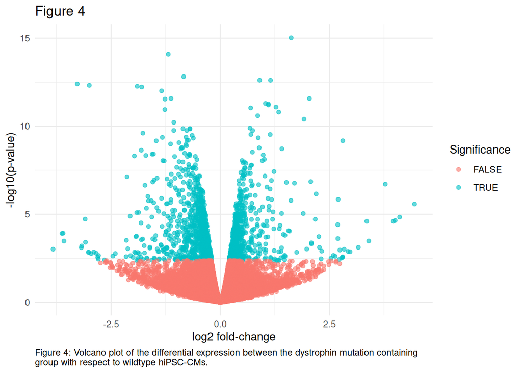

```r
# Calculate and add column if p-value is under threshold
volcano_df <- model_results  %>%
  tibble::rownames_to_column("hgnc") %>%
  mutate(sig = adj.P.Val < 0.05)

# Plot fold change by p-value color coded by threshold passing
ggplot(volcano_df, aes(x = logFC, y = -log10(P.Value), color = sig)) +
  geom_point(alpha = 0.6) +
  theme_minimal() +
  labs(
    title = "Figure 4",
    x = "log2 fold-change",
    y = "-log10(p-value)",
    color="Significance",
    caption=str_wrap("Figure 4: Volcano plot of the differential expression between the dystrophin mutation containing group with respect to wildtype hiPSC-CMs.", width=100)
  ) + theme(plot.caption = element_text(hjust = 0))
```

Using log fold-change in tandem with p-value the significant changes due to dystrophin can be expressed, seen in figure 4. Red points indicate non-significant results and are heavily populated. In addition, blue points represent changes that a statistically significant based on their adjusted p-value. There is an abundance of points that undergo a statistically change in regulation with the truncation of the dystrophin protein with the effect size densely populated within absolute value of 1 log fold change. Beyond this, drastic log fold changes are observed and statistically valid shown in the far left and right blue points of figure 4.

# Conclusions

The 3D cell culture study investigating the mechanisms of dystrophin in Duchenne Muscular Dystrophy is a homogeneous dataset in data preparation as there is consistent read coverage across the study’s samples. After normalizing the data and accounting the presence of duplicated genes, the differential gene expression analysis revealed a radical shift in genome-wide expression patterns between the wildtype dystrophin and mutated dystrophin genes. The genes that shift their direction of expression provide insights into possible DMD disease mechanism due to their relational change but a causal link is not identifiable here.

# References

Bremner, Samantha B, Christian J Mandrycky, Andrea Leonard, et al. 2022. “Full-Length Dystrophin Deficiency Leads to Contractile and Calcium Transient Defects in Human Engineered Heart Tissues.” *Journal of Tissue Engineering* 13 (January): 20417314221119628. https://doi.org/10.1177/20417314221119628.

Davis, Sean, and Paul S. Meltzer. 2007. “GEOquery: A Bridge Between the Gene Expression Omnibus (GEO) and BioConductor.” *Bioinformatics* 23 (14): 1846–47. https://doi.org/10.1093/bioinformatics/btm254.

Gu, Zuguang, Roland Eils, and Matthias Schlesner. 2016. “Complex Heatmaps Reveal Patterns and Correlations in Multidimensional Genomic Data.” *Bioinformatics* 32 (18): 2847–49. https://doi.org/10.1093/bioinformatics/btw313.

Ritchie, Matthew E., Belinda Phipson, Di Wu, et al. 2015. “Limma Powers Differential Expression Analyses for RNA-Sequencing and Microarray Studies.” *Nucleic Acids Research* 43 (7): e47–47. https://doi.org/10.1093/nar/gkv007.

Robinson, Mark D., Davis J. McCarthy, and Gordon K. Smyth. 2010. “edgeR : A Bioconductor Package for Differential Expression Analysis of Digital Gene Expression Data.” *Bioinformatics* 26 (1): 139–40. https://doi.org/10.1093/bioinformatics/btp616.

Smedley, Damian, Syed Haider, Benoit Ballester, et al. 2009. “BioMart – Biological Queries Made Easy.” *BMC Genomics* 10 (1): 22. https://doi.org/10.1186/1471-2164-10-22.

Stodden, Victoria, Friedrich Leisch, and Roger D. Peng, eds. 2014. *Implementing Reproducible Research*. Online-Ausg. The R Series. CRC Press.

Wickham, Hadley. 2016. “Data Analysis.” In *Ggplot2*. Springer International Publishing. https://doi.org/10.1007/978-3-319-24277-4_9.

Wickham, Hadley, Jim Hester, and Jennifer Bryan. 2025. *Readr: Read Rectangular Text Data*. https://readr.tidyverse.org.

Xie, Yihui. 2025. *Knitr: A General-Purpose Package for Dynamic Report Generation in R*. https://yihui.org/knitr/.